# Risk Factor Analysis

## Outcome Variable

**Outcome Variable:** pers_wasted624

## Predictor Variables

**Intervention Variable:** ever_stunted06

**Adjustment Set:**

unadjusted

## Stratifying Variables

The analysis was stratified on these variable(s):

- studyid
- country

## Data Summary

| studyid | country | ever_stunted06 | pers_wasted624 | n_cell | n |
| --- | --- | --- | --- | --- | --- |
| ki0047075b-MAL-ED | BANGLADESH | 0 | 0 | 149 | 240 |
| ki0047075b-MAL-ED | BANGLADESH | 0 | 1 | 11 | 240 |
| ki0047075b-MAL-ED | BANGLADESH | 1 | 0 | 73 | 240 |
| ki0047075b-MAL-ED | BANGLADESH | 1 | 1 | 7 | 240 |
| ki0047075b-MAL-ED | BRAZIL | 0 | 0 | 165 | 202 |
| ki0047075b-MAL-ED | BRAZIL | 0 | 1 | 2 | 202 |
| ki0047075b-MAL-ED | BRAZIL | 1 | 0 | 35 | 202 |
| ki0047075b-MAL-ED | BRAZIL | 1 | 1 | 0 | 202 |
| ki0047075b-MAL-ED | INDIA | 0 | 0 | 139 | 234 |
| ki0047075b-MAL-ED | INDIA | 0 | 1 | 15 | 234 |
| ki0047075b-MAL-ED | INDIA | 1 | 0 | 67 | 234 |
| ki0047075b-MAL-ED | INDIA | 1 | 1 | 13 | 234 |
| ki0047075b-MAL-ED | NEPAL | 0 | 0 | 194 | 234 |
| ki0047075b-MAL-ED | NEPAL | 0 | 1 | 1 | 234 |
| ki0047075b-MAL-ED | NEPAL | 1 | 0 | 38 | 234 |
| ki0047075b-MAL-ED | NEPAL | 1 | 1 | 1 | 234 |
| ki0047075b-MAL-ED | PERU | 0 | 0 | 144 | 264 |
| ki0047075b-MAL-ED | PERU | 0 | 1 | 0 | 264 |
| ki0047075b-MAL-ED | PERU | 1 | 0 | 118 | 264 |
| ki0047075b-MAL-ED | PERU | 1 | 1 | 2 | 264 |
| ki0047075b-MAL-ED | SOUTH AFRICA | 0 | 0 | 157 | 258 |
| ki0047075b-MAL-ED | SOUTH AFRICA | 0 | 1 | 2 | 258 |
| ki0047075b-MAL-ED | SOUTH AFRICA | 1 | 0 | 99 | 258 |
| ki0047075b-MAL-ED | SOUTH AFRICA | 1 | 1 | 0 | 258 |
| ki0047075b-MAL-ED | TANZANIA, UNITED REPUBLIC OF | 0 | 0 | 146 | 244 |
| ki0047075b-MAL-ED | TANZANIA, UNITED REPUBLIC OF | 0 | 1 | 0 | 244 |
| ki0047075b-MAL-ED | TANZANIA, UNITED REPUBLIC OF | 1 | 0 | 98 | 244 |
| ki0047075b-MAL-ED | TANZANIA, UNITED REPUBLIC OF | 1 | 1 | 0 | 244 |
| ki1000107-Serrinha-VitA | BRAZIL | 0 | 0 | 9 | 11 |
| ki1000107-Serrinha-VitA | BRAZIL | 0 | 1 | 1 | 11 |

[output cut: 126 more lines]

The following strata were considered:

- studyid: ki0047075b-MAL-ED, country: BANGLADESH
- studyid: ki0047075b-MAL-ED, country: BRAZIL
- studyid: ki0047075b-MAL-ED, country: INDIA
- studyid: ki0047075b-MAL-ED, country: NEPAL
- studyid: ki0047075b-MAL-ED, country: PERU
- studyid: ki0047075b-MAL-ED, country: SOUTH AFRICA
- studyid: ki0047075b-MAL-ED, country: TANZANIA, UNITED REPUBLIC OF
- studyid: ki1000107-Serrinha-VitA, country: BRAZIL
- studyid: ki1000108-CMC-V-BCS-2002, country: INDIA
- studyid: ki1000108-IRC, country: INDIA
- studyid: ki1000109-EE, country: PAKISTAN
- studyid: ki1000109-ResPak, country: PAKISTAN
- studyid: ki1000304-VITAMIN-A, country: INDIA
- studyid: ki1000304b-SAS-CompFeed, country: INDIA
- studyid: ki1000304b-SAS-FoodSuppl, country: INDIA
- studyid: ki1017093-NIH-Birth, country: BANGLADESH
- studyid: ki1017093b-PROVIDE, country: BANGLADESH
- studyid: ki1017093c-NIH-Crypto, country: BANGLADESH
- studyid: ki1033518-iLiNS-DYAD-G, country: GHANA
- studyid: ki1066203-TanzaniaChild2, country: TANZANIA, UNITED REPUBLIC OF
- studyid: ki1101329-Keneba, country: GAMBIA
- studyid: ki1112895-Burkina Faso Zn, country: BURKINA FASO
- studyid: ki1112895-Guatemala BSC, country: GUATEMALA
- studyid: ki1113344-GMS-Nepal, country: NEPAL
- studyid: ki1114097-CMIN, country: BANGLADESH
- studyid: ki1114097-CMIN, country: BRAZIL
- studyid: ki1114097-CMIN, country: GUINEA-BISSAU
- studyid: ki1114097-CMIN, country: PERU
- studyid: ki1114097-CONTENT, country: PERU
- studyid: ki1119695-PROBIT, country: BELARUS
- studyid: ki1126311-ZVITAMBO, country: ZIMBABWE
- studyid: ki1135781-COHORTS, country: GUATEMALA
- studyid: ki1135781-COHORTS, country: INDIA
- studyid: ki1135781-COHORTS, country: PHILIPPINES
- studyid: ki1148112-iLiNS-DOSE, country: MALAWI
- studyid: ki1148112-iLiNS-DYAD-M, country: MALAWI
- studyid: ki1148112-LCNI-5, country: MALAWI
- studyid: kiGH5241-JiVitA-3, country: BANGLADESH
- studyid: kiGH5241-JiVitA-4, country: BANGLADESH

### Dropped Strata

Some strata were dropped due to rare outcomes:

- studyid: ki0047075b-MAL-ED, country: BRAZIL
- studyid: ki0047075b-MAL-ED, country: NEPAL
- studyid: ki0047075b-MAL-ED, country: PERU
- studyid: ki0047075b-MAL-ED, country: SOUTH AFRICA
- studyid: ki0047075b-MAL-ED, country: TANZANIA, UNITED REPUBLIC OF
- studyid: ki1000107-Serrinha-VitA, country: BRAZIL
- studyid: ki1112895-Burkina Faso Zn, country: BURKINA FASO
- studyid: ki1112895-Guatemala BSC, country: GUATEMALA
- studyid: ki1114097-CMIN, country: BANGLADESH
- studyid: ki1114097-CMIN, country: BRAZIL
- studyid: ki1114097-CMIN, country: PERU
- studyid: ki1114097-CONTENT, country: PERU
- studyid: ki1119695-PROBIT, country: BELARUS
- studyid: ki1148112-LCNI-5, country: MALAWI

## Methods Detail

We’re interested in the causal parameters $E[Y_a]$ for all values of $a \in \mathcal{A}$. These parameters represent the mean outcome if, possibly contrary to fact, we intervened to set all units to have $A=a$. Under the randomization and positivity assumptions, these are identified by the statistical parameters $\psi_a=E_W[E_{Y|A,W}(Y|A=a,W)]$. In addition, we’re interested in the mean of $Y$, $E[Y]$ under no intervention (the observed mean). We will estimate these parameters by using SuperLearner to fit the relevant likelihood factors – $E_{Y|A,W}(Y|A=a,W)$ and $p(A=a|W)$, and then updating our likelihood fit using a joint TMLE.

For unadjusted analyses ($W=\{\}$), initial likelihoods were estimated using Lrnr_glm to estimate the simple $E(Y|A)$ and Lrnr_mean to estimate $p(A)$. For adjusted analyses, a small library containing Lrnr_glmnet, Lrnr_xgboost, and Lrnr_mean was used.

Having estimated these parameters, we will then use the delta method to estimate relative risks and attributable risks relative to a prespecified baseline level of $A$.

# Results Detail

## Results Plots

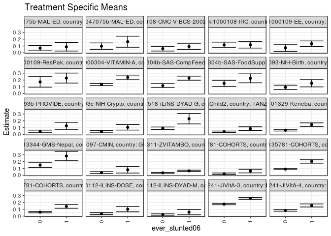

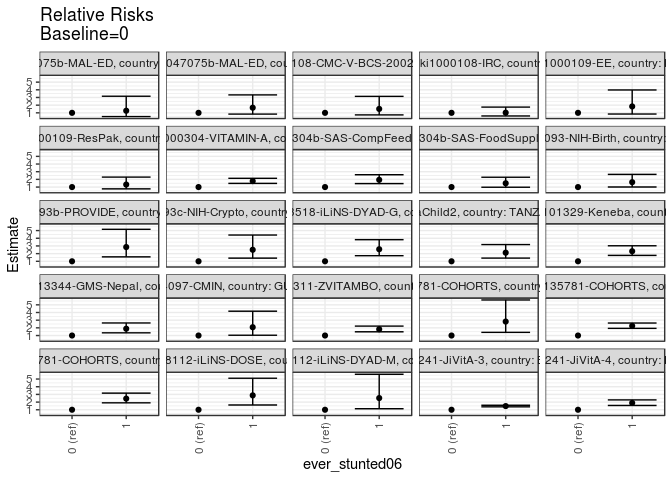

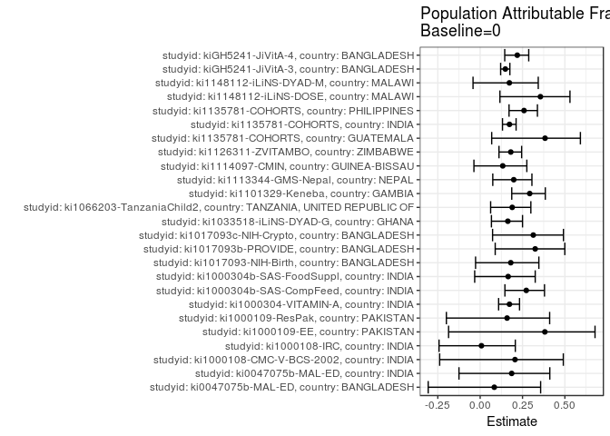

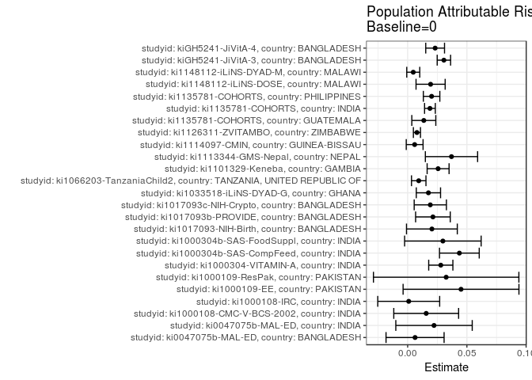

## Results Table

### Parameter: TSM

| studyid | country | intervention_level | baseline_level | estimate | ci_lower | ci_upper |
| --- | --- | --- | --- | --- | --- | --- |
| ki0047075b-MAL-ED | BANGLADESH | 0 | NA | 0.0687500 | 0.0294616 | 0.1080384 |
| ki0047075b-MAL-ED | BANGLADESH | 1 | NA | 0.0875000 | 0.0254517 | 0.1495483 |
| ki0047075b-MAL-ED | INDIA | 0 | NA | 0.0974026 | 0.0504727 | 0.1443325 |
| ki0047075b-MAL-ED | INDIA | 1 | NA | 0.1625000 | 0.0814875 | 0.2435125 |
| ki1000108-CMC-V-BCS-2002 | INDIA | 0 | NA | 0.0604396 | 0.0257718 | 0.0951074 |
| ki1000108-CMC-V-BCS-2002 | INDIA | 1 | NA | 0.0913978 | 0.0499275 | 0.1328682 |
| ki1000108-IRC | INDIA | 0 | NA | 0.1161826 | 0.0756764 | 0.1566888 |
| ki1000108-IRC | INDIA | 1 | NA | 0.1183432 | 0.0695840 | 0.1671024 |
| ki1000109-EE | PAKISTAN | 0 | NA | 0.0729167 | 0.0208370 | 0.1249963 |
| ki1000109-EE | PAKISTAN | 1 | NA | 0.1335740 | 0.0934580 | 0.1736900 |
| ki1000109-ResPak | PAKISTAN | 0 | NA | 0.1720430 | 0.0951621 | 0.2489239 |
| ki1000109-ResPak | PAKISTAN | 1 | NA | 0.2283465 | 0.1551746 | 0.3015183 |
| ki1000304-VITAMIN-A | INDIA | 0 | NA | 0.1337693 | 0.1174979 | 0.1500407 |
| ki1000304-VITAMIN-A | INDIA | 1 | NA | 0.2378641 | 0.2042881 | 0.2714401 |
| ki1000304b-SAS-CompFeed | INDIA | 0 | NA | 0.1167076 | 0.0876924 | 0.1457229 |
| ki1000304b-SAS-CompFeed | INDIA | 1 | NA | 0.2270169 | 0.1971073 | 0.2569264 |
| ki1000304b-SAS-FoodSuppl | INDIA | 0 | NA | 0.1502146 | 0.1042800 | 0.1961492 |
| ki1000304b-SAS-FoodSuppl | INDIA | 1 | NA | 0.2243590 | 0.1588129 | 0.2899051 |
| ki1017093-NIH-Birth | BANGLADESH | 0 | NA | 0.0928144 | 0.0616646 | 0.1239642 |
| ki1017093-NIH-Birth | BANGLADESH | 1 | NA | 0.1516854 | 0.0989365 | 0.2044342 |
| ki1017093b-PROVIDE | BANGLADESH | 0 | NA | 0.0443459 | 0.0253310 | 0.0633608 |
| ki1017093b-PROVIDE | BANGLADESH | 1 | NA | 0.1265823 | 0.0746935 | 0.1784711 |
| ki1017093c-NIH-Crypto | BANGLADESH | 0 | NA | 0.0418327 | 0.0243070 | 0.0593584 |
| ki1017093c-NIH-Crypto | BANGLADESH | 1 | NA | 0.1045455 | 0.0640867 | 0.1450042 |
| ki1033518-iLiNS-DYAD-G | GHANA | 0 | NA | 0.0898058 | 0.0702744 | 0.1093373 |
| ki1033518-iLiNS-DYAD-G | GHANA | 1 | NA | 0.2307692 | 0.1543851 | 0.3071534 |
| ki1066203-TanzaniaChild2 | TANZANIA, UNITED REPUBLIC OF | 0 | NA | 0.0400788 | 0.0302222 | 0.0499355 |
| ki1066203-TanzaniaChild2 | TANZANIA, UNITED REPUBLIC OF | 1 | NA | 0.0850000 | 0.0576630 | 0.1123370 |
| ki1101329-Keneba | GAMBIA | 0 | NA | 0.0622074 | 0.0499612 | 0.0744536 |
| ki1101329-Keneba | GAMBIA | 1 | NA | 0.1436865 | 0.1174889 | 0.1698842 |
| ki1113344-GMS-Nepal | NEPAL | 0 | NA | 0.1496437 | 0.1155394 | 0.1837480 |
| ki1113344-GMS-Nepal | NEPAL | 1 | NA | 0.2822086 | 0.2130556 | 0.3513615 |
| ki1114097-CMIN | GUINEA-BISSAU | 0 | NA | 0.0384106 | 0.0246941 | 0.0521271 |
| ki1114097-CMIN | GUINEA-BISSAU | 1 | NA | 0.0800000 | 0.0324140 | 0.1275860 |
| ki1126311-ZVITAMBO | ZIMBABWE | 0 | NA | 0.0354963 | 0.0309000 | 0.0400927 |
| ki1126311-ZVITAMBO | ZIMBABWE | 1 | NA | 0.0646006 | 0.0545341 | 0.0746671 |
| ki1135781-COHORTS | GUATEMALA | 0 | NA | 0.0219595 | 0.0101476 | 0.0337713 |
| ki1135781-COHORTS | GUATEMALA | 1 | NA | 0.0618893 | 0.0349208 | 0.0888577 |
| ki1135781-COHORTS | INDIA | 0 | NA | 0.0899633 | 0.0819528 | 0.0979738 |
| ki1135781-COHORTS | INDIA | 1 | NA | 0.2026477 | 0.1775042 | 0.2277911 |
| ki1135781-COHORTS | PHILIPPINES | 0 | NA | 0.0578118 | 0.0478113 | 0.0678122 |
| ki1135781-COHORTS | PHILIPPINES | 1 | NA | 0.1417798 | 0.1152229 | 0.1683366 |
| ki1148112-iLiNS-DOSE | MALAWI | 0 | NA | 0.0350877 | 0.0199730 | 0.0502025 |
| ki1148112-iLiNS-DOSE | MALAWI | 1 | NA | 0.1008403 | 0.0625610 | 0.1391196 |
| ki1148112-iLiNS-DYAD-M | MALAWI | 0 | NA | 0.0226501 | 0.0128222 | 0.0324779 |
| ki1148112-iLiNS-DYAD-M | MALAWI | 1 | NA | 0.0571429 | 0.0186371 | 0.0956486 |
| kiGH5241-JiVitA-3 | BANGLADESH | 0 | NA | 0.1753707 | 0.1665546 | 0.1841867 |
| kiGH5241-JiVitA-3 | BANGLADESH | 1 | NA | 0.2591951 | 0.2459812 | 0.2724089 |
| kiGH5241-JiVitA-4 | BANGLADESH | 0 | NA | 0.0826783 | 0.0716322 | 0.0937245 |
| kiGH5241-JiVitA-4 | BANGLADESH | 1 | NA | 0.1559748 | 0.1335138 | 0.1784359 |

### Parameter: E(Y)

| studyid | country | intervention_level | baseline_level | estimate | ci_lower | ci_upper |
| --- | --- | --- | --- | --- | --- | --- |
| ki0047075b-MAL-ED | BANGLADESH | NA | NA | 0.0750000 | 0.0416074 | 0.1083926 |
| ki0047075b-MAL-ED | INDIA | NA | NA | 0.1196581 | 0.0779840 | 0.1613323 |
| ki1000108-CMC-V-BCS-2002 | INDIA | NA | NA | 0.0760870 | 0.0489610 | 0.1032130 |
| ki1000108-IRC | INDIA | NA | NA | 0.1170732 | 0.0859146 | 0.1482317 |
| ki1000109-EE | PAKISTAN | NA | NA | 0.1179625 | 0.0851837 | 0.1507412 |
| ki1000109-ResPak | PAKISTAN | NA | NA | 0.2045455 | 0.1511224 | 0.2579685 |
| ki1000304-VITAMIN-A | INDIA | NA | NA | 0.1617391 | 0.1466878 | 0.1767905 |
| ki1000304b-SAS-CompFeed | INDIA | NA | NA | 0.1603563 | 0.1395035 | 0.1812092 |
| ki1000304b-SAS-FoodSuppl | INDIA | NA | NA | 0.1799486 | 0.1417254 | 0.2181718 |
| ki1017093-NIH-Birth | BANGLADESH | NA | NA | 0.1132813 | 0.0858017 | 0.1407608 |
| ki1017093b-PROVIDE | BANGLADESH | NA | NA | 0.0656814 | 0.0459906 | 0.0853723 |
| ki1017093c-NIH-Crypto | BANGLADESH | NA | NA | 0.0609418 | 0.0434802 | 0.0784034 |
| ki1033518-iLiNS-DYAD-G | GHANA | NA | NA | 0.1073326 | 0.0875449 | 0.1271203 |
| ki1066203-TanzaniaChild2 | TANZANIA, UNITED REPUBLIC OF | NA | NA | 0.0494277 | 0.0397346 | 0.0591208 |
| ki1101329-Keneba | GAMBIA | NA | NA | 0.0879121 | 0.0760335 | 0.0997906 |
| ki1113344-GMS-Nepal | NEPAL | NA | NA | 0.1866438 | 0.1550166 | 0.2182711 |
| ki1114097-CMIN | GUINEA-BISSAU | NA | NA | 0.0443182 | 0.0307131 | 0.0579233 |
| ki1126311-ZVITAMBO | ZIMBABWE | NA | NA | 0.0433251 | 0.0390011 | 0.0476491 |
| ki1135781-COHORTS | GUATEMALA | NA | NA | 0.0355951 | 0.0234770 | 0.0477132 |
| ki1135781-COHORTS | INDIA | NA | NA | 0.1087695 | 0.1008135 | 0.1167256 |
| ki1135781-COHORTS | PHILIPPINES | NA | NA | 0.0780116 | 0.0679971 | 0.0880261 |
| ki1148112-iLiNS-DOSE | MALAWI | NA | NA | 0.0544554 | 0.0387997 | 0.0701112 |
| ki1148112-iLiNS-DYAD-M | MALAWI | NA | NA | 0.0273705 | 0.0173577 | 0.0373833 |
| kiGH5241-JiVitA-3 | BANGLADESH | NA | NA | 0.2059588 | 0.1983834 | 0.2135343 |
| kiGH5241-JiVitA-4 | BANGLADESH | NA | NA | 0.1058706 | 0.0951082 | 0.1166330 |

### Parameter: RR

| studyid | country | intervention_level | baseline_level | estimate | ci_lower | ci_upper |
| --- | --- | --- | --- | --- | --- | --- |
| ki0047075b-MAL-ED | BANGLADESH | 0 | 0 | 1.000000 | 1.0000000 | 1.000000 |
| ki0047075b-MAL-ED | BANGLADESH | 1 | 0 | 1.272727 | 0.5119289 | 3.164179 |
| ki0047075b-MAL-ED | INDIA | 0 | 0 | 1.000000 | 1.0000000 | 1.000000 |
| ki0047075b-MAL-ED | INDIA | 1 | 0 | 1.668333 | 0.8340268 | 3.337226 |
| ki1000108-CMC-V-BCS-2002 | INDIA | 0 | 0 | 1.000000 | 1.0000000 | 1.000000 |
| ki1000108-CMC-V-BCS-2002 | INDIA | 1 | 0 | 1.512219 | 0.7277626 | 3.142242 |
| ki1000108-IRC | INDIA | 0 | 0 | 1.000000 | 1.0000000 | 1.000000 |
| ki1000108-IRC | INDIA | 1 | 0 | 1.018597 | 0.5937459 | 1.747447 |
| ki1000109-EE | PAKISTAN | 0 | 0 | 1.000000 | 1.0000000 | 1.000000 |
| ki1000109-EE | PAKISTAN | 1 | 0 | 1.831872 | 0.8441115 | 3.975488 |
| ki1000109-ResPak | PAKISTAN | 0 | 0 | 1.000000 | 1.0000000 | 1.000000 |
| ki1000109-ResPak | PAKISTAN | 1 | 0 | 1.327264 | 0.7658509 | 2.300225 |
| ki1000304-VITAMIN-A | INDIA | 0 | 0 | 1.000000 | 1.0000000 | 1.000000 |
| ki1000304-VITAMIN-A | INDIA | 1 | 0 | 1.778166 | 1.4758696 | 2.142381 |
| ki1000304b-SAS-CompFeed | INDIA | 0 | 0 | 1.000000 | 1.0000000 | 1.000000 |
| ki1000304b-SAS-CompFeed | INDIA | 1 | 0 | 1.945176 | 1.4523347 | 2.605261 |
| ki1000304b-SAS-FoodSuppl | INDIA | 0 | 0 | 1.000000 | 1.0000000 | 1.000000 |
| ki1000304b-SAS-FoodSuppl | INDIA | 1 | 0 | 1.493590 | 0.9784985 | 2.279830 |
| ki1017093-NIH-Birth | BANGLADESH | 0 | 0 | 1.000000 | 1.0000000 | 1.000000 |
| ki1017093-NIH-Birth | BANGLADESH | 1 | 0 | 1.634288 | 1.0079499 | 2.649831 |
| ki1017093b-PROVIDE | BANGLADESH | 0 | 0 | 1.000000 | 1.0000000 | 1.000000 |
| ki1017093b-PROVIDE | BANGLADESH | 1 | 0 | 2.854430 | 1.5772244 | 5.165893 |
| ki1017093c-NIH-Crypto | BANGLADESH | 0 | 0 | 1.000000 | 1.0000000 | 1.000000 |
| ki1017093c-NIH-Crypto | BANGLADESH | 1 | 0 | 2.499134 | 1.4128486 | 4.420623 |
| ki1033518-iLiNS-DYAD-G | GHANA | 0 | 0 | 1.000000 | 1.0000000 | 1.000000 |
| ki1033518-iLiNS-DYAD-G | GHANA | 1 | 0 | 2.569647 | 1.7292941 | 3.818369 |
| ki1066203-TanzaniaChild2 | TANZANIA, UNITED REPUBLIC OF | 0 | 0 | 1.000000 | 1.0000000 | 1.000000 |
| ki1066203-TanzaniaChild2 | TANZANIA, UNITED REPUBLIC OF | 1 | 0 | 2.120820 | 1.4147271 | 3.179324 |
| ki1101329-Keneba | GAMBIA | 0 | 0 | 1.000000 | 1.0000000 | 1.000000 |
| ki1101329-Keneba | GAMBIA | 1 | 0 | 2.309799 | 1.7662147 | 3.020681 |
| ki1113344-GMS-Nepal | NEPAL | 0 | 0 | 1.000000 | 1.0000000 | 1.000000 |
| ki1113344-GMS-Nepal | NEPAL | 1 | 0 | 1.885870 | 1.3495174 | 2.635391 |
| ki1114097-CMIN | GUINEA-BISSAU | 0 | 0 | 1.000000 | 1.0000000 | 1.000000 |
| ki1114097-CMIN | GUINEA-BISSAU | 1 | 0 | 2.082759 | 1.0407156 | 4.168174 |
| ki1126311-ZVITAMBO | ZIMBABWE | 0 | 0 | 1.000000 | 1.0000000 | 1.000000 |
| ki1126311-ZVITAMBO | ZIMBABWE | 1 | 0 | 1.819925 | 1.4861511 | 2.228661 |
| ki1135781-COHORTS | GUATEMALA | 0 | 0 | 1.000000 | 1.0000000 | 1.000000 |
| ki1135781-COHORTS | GUATEMALA | 1 | 0 | 2.818341 | 1.4104355 | 5.631628 |
| ki1135781-COHORTS | INDIA | 0 | 0 | 1.000000 | 1.0000000 | 1.000000 |
| ki1135781-COHORTS | INDIA | 1 | 0 | 2.252560 | 1.9335320 | 2.624226 |
| ki1135781-COHORTS | PHILIPPINES | 0 | 0 | 1.000000 | 1.0000000 | 1.000000 |
| ki1135781-COHORTS | PHILIPPINES | 1 | 0 | 2.452439 | 1.9004974 | 3.164675 |
| ki1148112-iLiNS-DOSE | MALAWI | 0 | 0 | 1.000000 | 1.0000000 | 1.000000 |
| ki1148112-iLiNS-DOSE | MALAWI | 1 | 0 | 2.873950 | 1.6185416 | 5.103104 |
| ki1148112-iLiNS-DYAD-M | MALAWI | 0 | 0 | 1.000000 | 1.0000000 | 1.000000 |
| ki1148112-iLiNS-DYAD-M | MALAWI | 1 | 0 | 2.522857 | 1.1319352 | 5.622944 |
| kiGH5241-JiVitA-3 | BANGLADESH | 0 | 0 | 1.000000 | 1.0000000 | 1.000000 |
| kiGH5241-JiVitA-3 | BANGLADESH | 1 | 0 | 1.477984 | 1.3778578 | 1.585387 |
| kiGH5241-JiVitA-4 | BANGLADESH | 0 | 0 | 1.000000 | 1.0000000 | 1.000000 |
| kiGH5241-JiVitA-4 | BANGLADESH | 1 | 0 | 1.886527 | 1.5592830 | 2.282448 |

### Parameter: PAR

| studyid | country | intervention_level | baseline_level | estimate | ci_lower | ci_upper |
| --- | --- | --- | --- | --- | --- | --- |
| ki0047075b-MAL-ED | BANGLADESH | 0 | NA | 0.0062500 | -0.0182560 | 0.0307560 |
| ki0047075b-MAL-ED | INDIA | 0 | NA | 0.0222555 | -0.0099973 | 0.0545083 |
| ki1000108-CMC-V-BCS-2002 | INDIA | 0 | NA | 0.0156474 | -0.0117183 | 0.0430131 |
| ki1000108-IRC | INDIA | 0 | NA | 0.0008906 | -0.0252384 | 0.0270196 |
| ki1000109-EE | PAKISTAN | 0 | NA | 0.0450458 | -0.0038479 | 0.0939395 |
| ki1000109-ResPak | PAKISTAN | 0 | NA | 0.0325024 | -0.0288774 | 0.0938823 |
| ki1000304-VITAMIN-A | INDIA | 0 | NA | 0.0279698 | 0.0177686 | 0.0381710 |
| ki1000304b-SAS-CompFeed | INDIA | 0 | NA | 0.0436487 | 0.0268725 | 0.0604249 |
| ki1000304b-SAS-FoodSuppl | INDIA | 0 | NA | 0.0297340 | -0.0025670 | 0.0620350 |
| ki1017093-NIH-Birth | BANGLADESH | 0 | NA | 0.0204669 | -0.0009687 | 0.0419025 |
| ki1017093b-PROVIDE | BANGLADESH | 0 | NA | 0.0213355 | 0.0067145 | 0.0359566 |
| ki1017093c-NIH-Crypto | BANGLADESH | 0 | NA | 0.0191092 | 0.0055099 | 0.0327084 |
| ki1033518-iLiNS-DYAD-G | GHANA | 0 | NA | 0.0175268 | 0.0072829 | 0.0277707 |
| ki1066203-TanzaniaChild2 | TANZANIA, UNITED REPUBLIC OF | 0 | NA | 0.0093488 | 0.0032463 | 0.0154514 |
| ki1101329-Keneba | GAMBIA | 0 | NA | 0.0257047 | 0.0164444 | 0.0349651 |
| ki1113344-GMS-Nepal | NEPAL | 0 | NA | 0.0370001 | 0.0149446 | 0.0590556 |
| ki1114097-CMIN | GUINEA-BISSAU | 0 | NA | 0.0059076 | -0.0011922 | 0.0130073 |
| ki1126311-ZVITAMBO | ZIMBABWE | 0 | NA | 0.0078288 | 0.0048395 | 0.0108181 |
| ki1135781-COHORTS | GUATEMALA | 0 | NA | 0.0136356 | 0.0035056 | 0.0237657 |
| ki1135781-COHORTS | INDIA | 0 | NA | 0.0188063 | 0.0142732 | 0.0233393 |
| ki1135781-COHORTS | PHILIPPINES | 0 | NA | 0.0201999 | 0.0132429 | 0.0271568 |
| ki1148112-iLiNS-DOSE | MALAWI | 0 | NA | 0.0193677 | 0.0070701 | 0.0316653 |
| ki1148112-iLiNS-DYAD-M | MALAWI | 0 | NA | 0.0047204 | -0.0007666 | 0.0102074 |
| kiGH5241-JiVitA-3 | BANGLADESH | 0 | NA | 0.0305882 | 0.0249359 | 0.0362404 |
| kiGH5241-JiVitA-4 | BANGLADESH | 0 | NA | 0.0231923 | 0.0152607 | 0.0311239 |

### Parameter: PAF

| studyid | country | intervention_level | baseline_level | estimate | ci_lower | ci_upper |
| --- | --- | --- | --- | --- | --- | --- |
| ki0047075b-MAL-ED | BANGLADESH | 0 | NA | 0.0833333 | -0.3066636 | 0.3569288 |
| ki0047075b-MAL-ED | INDIA | 0 | NA | 0.1859926 | -0.1250318 | 0.4110317 |
| ki1000108-CMC-V-BCS-2002 | INDIA | 0 | NA | 0.2056515 | -0.2389864 | 0.4907211 |
| ki1000108-IRC | INDIA | 0 | NA | 0.0076072 | -0.2426583 | 0.2074704 |
| ki1000109-EE | PAKISTAN | 0 | NA | 0.3818655 | -0.1863664 | 0.6779324 |
| ki1000109-ResPak | PAKISTAN | 0 | NA | 0.1589008 | -0.1993544 | 0.4101428 |
| ki1000304-VITAMIN-A | INDIA | 0 | NA | 0.1729316 | 0.1089169 | 0.2323475 |
| ki1000304b-SAS-CompFeed | INDIA | 0 | NA | 0.2721983 | 0.1460818 | 0.3796885 |
| ki1000304b-SAS-FoodSuppl | INDIA | 0 | NA | 0.1652361 | -0.0323167 | 0.3249834 |
| ki1017093-NIH-Birth | BANGLADESH | 0 | NA | 0.1806731 | -0.0270884 | 0.3464083 |
| ki1017093b-PROVIDE | BANGLADESH | 0 | NA | 0.3248337 | 0.0888089 | 0.4997213 |
| ki1017093c-NIH-Crypto | BANGLADESH | 0 | NA | 0.3135639 | 0.0732892 | 0.4915410 |
| ki1033518-iLiNS-DYAD-G | GHANA | 0 | NA | 0.1632942 | 0.0665262 | 0.2500309 |
| ki1066203-TanzaniaChild2 | TANZANIA, UNITED REPUBLIC OF | 0 | NA | 0.1891417 | 0.0618320 | 0.2991754 |
| ki1101329-Keneba | GAMBIA | 0 | NA | 0.2923913 | 0.1864402 | 0.3845442 |
| ki1113344-GMS-Nepal | NEPAL | 0 | NA | 0.1982392 | 0.0744540 | 0.3054690 |
| ki1114097-CMIN | GUINEA-BISSAU | 0 | NA | 0.1332994 | -0.0368065 | 0.2754965 |
| ki1126311-ZVITAMBO | ZIMBABWE | 0 | NA | 0.1806991 | 0.1111227 | 0.2448294 |
| ki1135781-COHORTS | GUATEMALA | 0 | NA | 0.3830764 | 0.0680879 | 0.5915981 |
| ki1135781-COHORTS | INDIA | 0 | NA | 0.1729001 | 0.1317960 | 0.2120581 |
| ki1135781-COHORTS | PHILIPPINES | 0 | NA | 0.2589340 | 0.1704530 | 0.3379774 |
| ki1148112-iLiNS-DOSE | MALAWI | 0 | NA | 0.3556619 | 0.1166719 | 0.5299916 |
| ki1148112-iLiNS-DYAD-M | MALAWI | 0 | NA | 0.1724640 | -0.0420866 | 0.3428417 |
| kiGH5241-JiVitA-3 | BANGLADESH | 0 | NA | 0.1485159 | 0.1208296 | 0.1753304 |
| kiGH5241-JiVitA-4 | BANGLADESH | 0 | NA | 0.2190629 | 0.1450520 | 0.2866669 |